# 6372: Unit 10 & 11 Homework

Matt Farrow

## Proportion Conceptual questions

1. State under what circumstance that a difference in proportion confidence interval or test should not be used in favor of an odds ratio metric.

$\qquad$ When a result is of statistical significance, but not necessarily practical significance, an odds ratio metric is more appropriate.

2. Under what sampling schemes can a hypothesis test be generally worded as a “test for association”, rather than a test for difference in proportion, odds, or relative risk?

$\qquad$ Retrospective observational studies.

3. It might be tempting in a predictive model setting (using a test set) to obtain a count of correct vs incorrect predictions for two or more modeling approaches. Imagine that the classification accuracy on a test set of 200 observations for model 1 is 0.82 while for model 2 it was 0.80. To determine that one model is actually predicting “better”" than the other in terms of overall accuracy, you produce a confidence interval for the difference in proportion of correctly predicted observations and the interval does not contain 0. Why is this type of analysis using a 2x2 count table inappropriate?
4. Give an example of study that could not be conducted in a prospective manner due to either logistical or ethical considerations.

$\qquad$ Any sort of study that involves illegal or dangerous behavior would not be appropriate for a prospective study..

5. What metric allows for the following interpretation: “The chances of a person getting the flu who has not taken the flu vaccine is thirty percent (1.3 times) higher than someone who has taken the flu vaccine”?

$\qquad$ Risk ratio.

## Exercise #1: Basic Tools

The *Statistical Sleuth* only considers statistical inference and estimation for two by two count tables in which a comparison is needed. However, it is often useful to perform inference on a single population proportion (think 1 sample t-test for a binary outcome). The technical details and formulas can be easily obtained on line or in a text book, the following example illustrates how to produce a z-test and confidence interval for a single proportion. The same function can be used for the difference in proportions.

Consider the Vitamin C study on flu occurrences in which study members either took a placebo or Vitamin C tablets prior to a flu season and they continued to take the supplement throughout the study. Does Vitamin C have any effect on the occurrence of flu?

Suppose for the moment a study was conducted just on a placebo group to understand what the general rate of flu outbreak is for an “average” person. The `prop.test` function allows us to estimate the proportion of this population and generate a confidence interval. Additional z-testing can be done by specifying a null hypothesized value but we will not worry about that here. Since 335 out of 411 people obtained the flu, the following code generates inference for a single population proportion:

```r
prop.test(335, 411, p = .7, correct = TRUE) # 'correct' is the continuity correction option
```

```
##
##  1-sample proportions test with continuity correction
##
## data:  335 out of 411, null probability 0.7
## X-squared = 25.376, df = 1, p-value = 4.716e-07
## alternative hypothesis: true p is not equal to 0.7
## 95 percent confidence interval:
##  0.7733959 0.8507513
## sample estimates:
##         p
## 0.8150852
```

Similar to SAS `proc freq`, categorical analysis in R requires information on the counts of key variables of interest (response and explanatory). Usually this requires an additional step when working from a data file that has a traditional format (each row is an observation, columns are variables). To illustrate how this would work, let’s create a traditional data set out of the Vitamin C study. First we will create a data set, and use `table` to aggregate the data into a 2x2 count matrix. I will then give an example of how to directly create a count table manually.

```r
vit.c <- data.frame(
  Supp = rep(c("Placebo", "Vitamin C"), times = c(411, 407)),
  Cold = rep(c("Yes", "No", "Yes", "No"), times = c(335, 76, 302, 105))
)
head(vit.c)
```

```
##      Supp Cold
## 1 Placebo  Yes
## 2 Placebo  Yes
## 3 Placebo  Yes
## 4 Placebo  Yes
## 5 Placebo  Yes
## 6 Placebo  Yes
```

```r
mymat <- table(vit.c) # or table(vit.c$Supp,vit.c$Cold)
mymat
```

```
##            Cold
## Supp         No Yes
##   Placebo    76 335
##   Vitamin C 105 302
```

Note here we could have created the table ourselves by just creating a matrix.

```r
mymat <-
  matrix(c(76, 335, 105, 302),
         2,
         2,
         byrow = T,
         dimnames = list(c("Placebo", "Vitamin C"), c("No", "Yes")))
```

As discussed in the analysis plan of live session, a common approach to streamline the analysis of 2x2 contingency tables is to run either a Fisher’s Exact Test or a Pearson’s Chi-squared test with Yates’ contuinuity correction to answer the key hypothesis question at hand. The following is an example of how to do both. At this stage the format of `mymat` doesn’t matter, the p-value will be the same regardless of how the rows and columns are situated.

```r
# Conducting a Fisher's Exact Test
fisher.test(mymat)
```

```
##
##  Fisher's Exact Test for Count Data
##
## data:  mymat
## p-value = 0.01444
## alternative hypothesis: true odds ratio is not equal to 1
## 95 percent confidence interval:
##  0.4603013 0.9229415
## sample estimates:
## odds ratio
##  0.6528601
```

```r
# Conducting a Pearson's Chi-squared test
chisq.test(mymat, correct = TRUE)
```

```
##
##  Pearson's Chi-squared test with Yates' continuity correction
##
## data:  mymat
## X-squared = 5.9196, df = 1, p-value = 0.01497
```

Note here that the sample sizes are quite big for the two groups; the p-value for both tests correspond quite nicely here because of this.

Another helpful tool is the ability to look at the proportions of the table rather than the raw counts. This is where it is helpful to have a good understanding of how your matrix is formatted. Since my rows are the explanatory variable I want the proportions to be obtained via each row (`margin = 1` for rows, `margin = 2` for columns).

```r
prop.table(mymat, margin = 1)
```

```
##                  No       Yes
## Placebo   0.1849148 0.8150852
## Vitamin C 0.2579853 0.7420147
```

Make note the proportion of No’s for each group. This will come in handy later for interpretation of confidence intervals.

Turning our attention now to confidence intervals, these can be obtained from various packages. Differences in proportions are easily obtained using the previous `prop.test` function. For the odds ratio and relative risk metrics, we will obtain these from the `epitools` package.

```r
# Confidence intervals for proportions
prop.test(mymat, correct = TRUE)
```

```
##
##  2-sample test for equality of proportions with continuity correction
##
## data:  mymat
## X-squared = 5.9196, df = 1, p-value = 0.01497
## alternative hypothesis: two.sided
## 95 percent confidence interval:
##  -0.13222111 -0.01391972
## sample estimates:
##    prop 1    prop 2
## 0.1849148 0.2579853
```

Here is where we have to be careful with the output. Note the proportion table we made previously. The confidence intervals and estimates are for the proportions of people who did not get the cold rather than the proportion of people who did get the cold. To swap it around we can do the following:

```r
prop.test(mymat[, c(2, 1)], correct = TRUE)
```

```
##
##  2-sample test for equality of proportions with continuity correction
##
## data:  mymat[, c(2, 1)]
## X-squared = 5.9196, df = 1, p-value = 0.01497
## alternative hypothesis: two.sided
## 95 percent confidence interval:
##  0.01391972 0.13222111
## sample estimates:
##    prop 1    prop 2
## 0.8150852 0.7420147
```

Further, if we wanted to compare the second group to the first rather than the first to the second, we could simply swap the rows. This is made easier for the other metrics using the `epitools` package.

```r
prop.test(mymat[c(2, 1), c(2, 1)], correct = TRUE)
```

```
##
##  2-sample test for equality of proportions with continuity correction
##
## data:  mymat[c(2, 1), c(2, 1)]
## X-squared = 5.9196, df = 1, p-value = 0.01497
## alternative hypothesis: two.sided
## 95 percent confidence interval:
##  -0.13222111 -0.01391972
## sample estimates:
##    prop 1    prop 2
## 0.7420147 0.8150852
```

As you dive through the output from these calls, you should be coming to a realization that it doesn’t really matter if you define proportion of `Yes` or `No` or `Group A` vs. `Group B`, the results all tell you the same thing. *(See Sleuth Ch. 18 Exercise 5 for a detailed look)*

Confidence intervals for odds ratios and relative risk can be obtained using the `epitools` package. The choice of which metric to use is up to you.

```r
library(epitools)

# Another way to format a count matrix
mymat <- matrix(c(76, 335, 105, 302), 2, 2, byrow = T)
dimnames(mymat) <- list("Treatment" = c("Plac", "Vit C"), "Response" = c("No", "Yes"))
mymat
```

```
##          Response
## Treatment  No Yes
##     Plac   76 335
##     Vit C 105 302
```

```r
# Odds Ratio Intervals
oddsratio.wald(mymat)
```

```
## $data
##          Response
## Treatment  No Yes Total
##     Plac   76 335   411
##     Vit C 105 302   407
##     Total 181 637   818
##
## $measure
##          odds ratio with 95% C.I.
## Treatment  estimate     lower     upper
##     Plac  1.0000000        NA        NA
##     Vit C 0.6525089 0.4673981 0.9109319
##
## $p.value
##          two-sided
## Treatment midp.exact fisher.exact chi.square
##     Plac          NA           NA         NA
##     Vit C 0.01201242   0.01444212 0.01182729
##
## $correction
## [1] FALSE
##
## attr(,"method")
## [1] "Unconditional MLE & normal approximation (Wald) CI"
```

```r
# Relative Risk Intervals
riskratio.wald(mymat)
```

```
## $data
##          Response
## Treatment  No Yes Total
##     Plac   76 335   411
##     Vit C 105 302   407
##     Total 181 637   818
##
## $measure
##          risk ratio with 95% C.I.
## Treatment  estimate     lower     upper
##     Plac  1.0000000        NA        NA
##     Vit C 0.9103524 0.8458427 0.9797821
##
## $p.value
##          two-sided
## Treatment midp.exact fisher.exact chi.square
##     Plac          NA           NA         NA
##     Vit C 0.01201242   0.01444212 0.01182729
##
## $correction
## [1] FALSE
##
## attr(,"method")
## [1] "Unconditional MLE & normal approximation (Wald) CI"
```

### Homework Questions

6. Consider the last bit of output from `oddsratio.wald(mymat)`, where the estimate and confidence interval for the odds ratio is reported. What is the ratio currently for? Odds (Y:N) or (N:Y) and is placebo on top or is placebo on bottom?

```r
oddsratio.wald(mymat)$measure
```

```
##          odds ratio with 95% C.I.
## Treatment  estimate     lower     upper
##     Plac  1.0000000        NA        NA
##     Vit C 0.6525089 0.4673981 0.9109319
```

7. Rerun the `oddsratio.wald` function but include the option `(rev = "both")` or maybe try `rev = "rows"` or `rev = "columns"`. Determine which version(s) produces the odds ratio when we want the odds (Y:N) for the placebo group over the odds (Y:N) for the Vitamin C group.

```r
oddsratio.wald(mymat, rev = "both")$measure
```

```
##          odds ratio with 95% C.I.
## Treatment  estimate     lower     upper
##     Vit C 1.0000000        NA        NA
##     Plac  0.6525089 0.4673981 0.9109319
```

```r
oddsratio.wald(mymat, rev = "rows")$measure
```

```
##          odds ratio with 95% C.I.
## Treatment estimate    lower    upper
##     Vit C 1.000000       NA       NA
##     Plac  1.532546 1.097777 2.139504
```

```r
oddsratio.wald(mymat, rev = "columns")$measure
```

```
##          odds ratio with 95% C.I.
## Treatment estimate    lower    upper
##     Plac  1.000000       NA       NA
##     Vit C 1.532546 1.097777 2.139504
```

$\qquad$ It looks like `rev = "rows"` shows us the data in the format that we’re looking for.

8. Rinse and repeat #1 and #2 for the relative risk calculation. What proportions (Yes or No) are being used to calculate the relative risk and which group is on top of the ratio? Use the `rev` option to swap things around so that the relative risk metric is (proportion of Yes placebo group over the proportion of yes for the Vitamin C group).

```r
riskratio.wald(mymat)$measure
```

```
##          risk ratio with 95% C.I.
## Treatment  estimate     lower     upper
##     Plac  1.0000000        NA        NA
##     Vit C 0.9103524 0.8458427 0.9797821
```

```r
riskratio.wald(mymat, rev = "both")$measure
```

```
##          risk ratio with 95% C.I.
## Treatment  estimate     lower     upper
##     Vit C 1.0000000        NA        NA
##     Plac  0.7167651 0.5518731 0.9309247
```

```r
riskratio.wald(mymat, rev = "rows")$measure
```

```
##          risk ratio with 95% C.I.
## Treatment estimate    lower    upper
##     Vit C 1.000000       NA       NA
##     Plac  1.098476 1.020635 1.182253
```

```r
riskratio.wald(mymat, rev = "columns")$measure
```

```
##          risk ratio with 95% C.I.
## Treatment estimate    lower    upper
##     Plac  1.000000       NA       NA
##     Vit C 1.395157 1.074201 1.812011
```

Note: The whole point of these questions is to get you experienced with the idea of swapping estimates around to get at the most comfortable interpretation of the metric you would like to report. It’ll force you to appreciate that you can’t trust the output directly; don’t forget you can always do a hand calculation to make sure what is being reported makes sense.

9. Conduct an analysis of the study reported in the Sleuth book Ch. 18 Exercise #7. Make sure to comment on the study design and which metrics are available to use, conduct your analysis, and write a conclusion to answer the researchers question “Is alcoholic beverage consumption associated with breast cancer?”

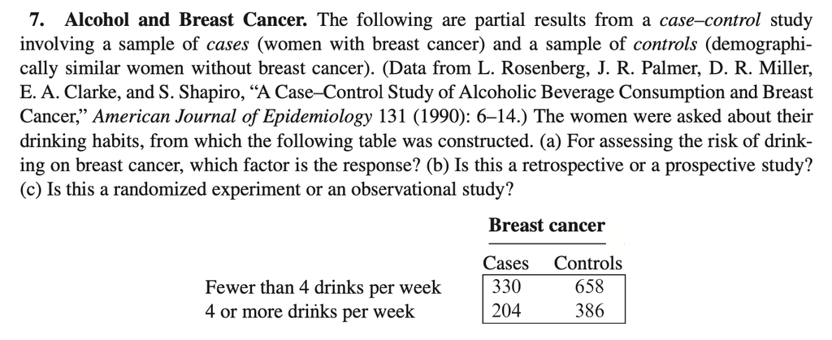

Statistical Sleuth, Chapter 18, Exercise 7

```r
knitr::include_graphics(here::here("6372", "week 11", "sleuth18.7.png"))
```

$\qquad$ This is a retrospective, observational study. The odds of women getting cancer who have fewer than 4 drinks per week is 0.949 times less than the odds of women who have 4 or more drinks per week (95% confidence interval: 0.7655, 1.1766).

## Exercise #2: Mantel-Haenszel Tests

Like the `table` function previously discussed, the most realistic way to generate a table for Mantel-Haenszel Tests is from aggregating a data set from a more traditional format. Sticking with the theme of the Vitamin C study, Ch. 19 exercise 16 provides a hypothetical extension to the study that also kept track of whether each patient knew they were in the placebo or treatment group ahead of time. Sometimes people can just figure it out. The question now becomes, is the conclusion of the single 2x2 analysis still remain consistent after adjusting for this additional factor? *(Note: This is just a fabricated data set. Use the text to take a look at the tables of numbers)*

This data set requires the knowledge of two 2x2 count tables (one for each knowledge group).

```r
vit.c <- data.frame(
  Supp = rep(
    c("Placebo", "Vitamin C", "Placebo", "Vitamin C"),
    times = c(312, 168, 88, 232)
  ),
  Cold = rep(
    c("Yes", "No", "Yes", "No", "Yes", "No", "Yes", "No"),
    times = c(266, 46, 139, 29, 62, 26, 157, 75)
  ),
  Known = rep(c("Yes", "No"), times = c(480, 320))
)
head(vit.c)
```

```
##      Supp Cold Known
## 1 Placebo  Yes   Yes
## 2 Placebo  Yes   Yes
## 3 Placebo  Yes   Yes
## 4 Placebo  Yes   Yes
## 5 Placebo  Yes   Yes
## 6 Placebo  Yes   Yes
```

```r
# Going from a standard file to generate tables for each group
mytable <- table(vit.c) # note here the order of the columns of vit.c matters. The last column should be the stratification variable.

mytable
```

```
## , , Known = No
##
##            Cold
## Supp         No Yes
##   Placebo    26  62
##   Vitamin C  75 157
##
## , , Known = Yes
##
##            Cold
## Supp         No Yes
##   Placebo    46 266
##   Vitamin C  29 139
```

At this point we may want to edit the tables to format the odds ratio in a way we’d prefer to read them. Reordering the tables is easy, we are just using arrays instead of matrices. The 3rd dimension is the “known” status which we do not care of the order that it is in.

```r
# Rearranging the order of tables so that Yes's are first. Placebo is already on top.
library(samplesizeCMH)
mytable <- mytable[, c(2, 1), ] # Odds (Y:N) Placebo over
mytable
```

```
## , , Known = No
##
##            Cold
## Supp        Yes  No
##   Placebo    62  26
##   Vitamin C 157  75
##
## , , Known = Yes
##
##            Cold
## Supp        Yes  No
##   Placebo   266  46
##   Vitamin C 139  29
```

```r
# Comparing the odds for each known category (Yes they knew their group, no they didn't)
apply(mytable, 3, odds.ratio)
```

```
##       No      Yes
## 1.139147 1.206444
```

Please note that the Yes/No table above is not the Yes/No variable for whether they have the flu or not. The `apply` function takes `mytable` and calculates the odds ratio for each of the 2 tables (the 3 index says use the 3rd column of table array which is what stratifies the tables to begin with.) Here we can see that the odds ratios are pretty consistent. A Breslow-Day test can confirm this. This test is available in various packages of which I have had a hard time installing. `DescTools` looks to be the most promising but I had troubles.

Assuming that a common odds ratio exists across the groups of patients who knew their treatment status, the Mantel-Haenszel test can be applied.

```r
mantelhaen.test(mytable)
```

```
##
##  Mantel-Haenszel chi-squared test with continuity correction
##
## data:  mytable
## Mantel-Haenszel X-squared = 0.57345, df = 1, p-value = 0.4489
## alternative hypothesis: true common odds ratio is not equal to 1
## 95 percent confidence interval:
##  0.811711 1.696612
## sample estimates:
## common odds ratio
##          1.173524
```

### Homework Questions

10. Ignore the known status variable and conduct a standard 2x2 analysis from a collapsed table. Provide the Fisher’s Exact Test and a confidence interval for the odds ratio and compare it to the previous Mantel-Haenszel test results. The result of this comparison really shows how patients not being blinded to the treatment group can really impact the overall estimates of parameters like odds ratios as well as the hypothesis test conclusions.

```r
# Another way to format a count matrix
mymat <- matrix(c(328, 72, 296, 104), 2, 2, byrow = T)
dimnames(mymat) <- list("Supp" = c("Placebo", "Vitamin C"), "Response" = c("No", "Yes"))
mymat
```

[output not shown]

```r
# Odds Ratio Intervals
oddsratio.wald(mymat)$p.value
```

```
##            two-sided
## Supp         midp.exact fisher.exact  chi.square
##   Placebo            NA           NA          NA
##   Vitamin C 0.006402168  0.008036599 0.006311279
```

11. Consider Chapter 19 Exercise 17 out of Statistical Sleuth. It is an extension to the alcohol/breast cancer study you previously did. Perform the Mantel-Haenszel test procedure after taking into account the individual women’s body mass as this could be a confounding factor. (Use `?mantelhaen.test` for one example of writing the data set into an array table if you don’t want to make a big data set up front like I did in the example code.)

```r
# Make a matrix
alcohol <- tibble(drinks = rep(c("At least one drink per day",
                                 "Less than one drink per month"),
                               times = c(309, 557)),
                  groups = rep(c("Cases", "Controls"),
                               times = c(309, 557)),
                  bmi = rep(c("< 21 kg/m^2",
                              "> 25 kg/m^2",
                              "21-25 kg/m^2",
                              "< 21 kg/m^2",
                              "> 25 kg/m^2",
                              "21-25 kg/m^2"),
                            times = c(64, 86, 159, 113, 144, 300))
                  )

# Make a table
alcohol_table <- table(alcohol)

# Look at the table
alcohol_table
```

```
## , , bmi = < 21 kg/m^2
##
##                                groups
## drinks                          Cases Controls
##   At least one drink per day       64        0
##   Less than one drink per month     0      113
##
## , , bmi = > 25 kg/m^2
##
##                                groups
## drinks                          Cases Controls
##   At least one drink per day       86        0
##   Less than one drink per month     0      144
##
## , , bmi = 21-25 kg/m^2
##
##                                groups
## drinks                          Cases Controls
##   At least one drink per day      159        0
##   Less than one drink per month     0      300
```

```r
# Mantel-Haenszel Test
mantelhaen.test(alcohol_table)
```

```
##
##  Mantel-Haenszel chi-squared test with continuity correction
##
## data:  alcohol_table
## Mantel-Haenszel X-squared = 858.45, df = 1, p-value < 2.2e-16
## alternative hypothesis: true common odds ratio is not equal to 1
## 95 percent confidence interval:
##  NaN NaN
## sample estimates:
## common odds ratio
##               Inf
```